# Praca domowa 2

Imię Nazwisko

## Dane

Dane wykorzystane w Pracy domowej 2 opisują wycenę nieruchmości. Każda obserwacja jest pewną nieruchmością, która posiada informacje takie jak powierzchnia, liczba pokoi, liczba łazienek i wiele więcj. Opis wszystkich kolumn w pliku `README.md`.

## Zadanie 1

Jak wygląda rozkład ceny nieruchomości w poszczególnych kodach pocztowych na przestrzeni lat? Rozważamy kody pocztowe, które mają więcej niż 280 posiadłości.

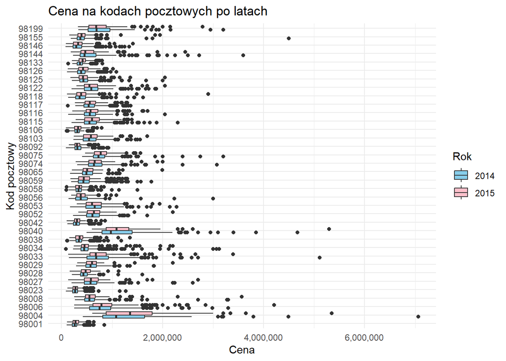

```r
# Tu umieść kod do wygenerowania odpowiedzi do zadania.

dane <- df %>%
  group_by(zipcode) %>%
  mutate(num_same_zipcode = n()) %>%
  ungroup() %>%
  filter(num_same_zipcode > 280) %>%
  mutate(Rok = substr(date, 1, 4)) %>% # daty sa podane w formacie YYYYMMDDT...
  mutate(zipcode = as.character(zipcode)) # zeby nie byla ciagla

wyk1 <- ggplot(dane, aes(x = zipcode, y = price, fill = Rok)) +
  geom_boxplot(position = position_dodge(width = 0.75)) +
  scale_y_continuous(labels = scales::comma_format()) +
  labs(title = "Cena na kodach pocztowych po latach",
       x = "Kod pocztowy",
       y = "Cena") +
  theme_minimal() +
  scale_fill_manual(values = c("2014" = "skyblue", "2015" = "pink")) +
  coord_flip()





wyk1
```

**Komentarz: W większości widocznych kodów pocztowych ceny nieznacznie wzrosły.**

## Zadanie 2

Czy jest różnica w rozkładzie ceny nierchomości od powierzchni mieszkalnej uwzględniając podział na nieruchomości z piwnicą i bez?

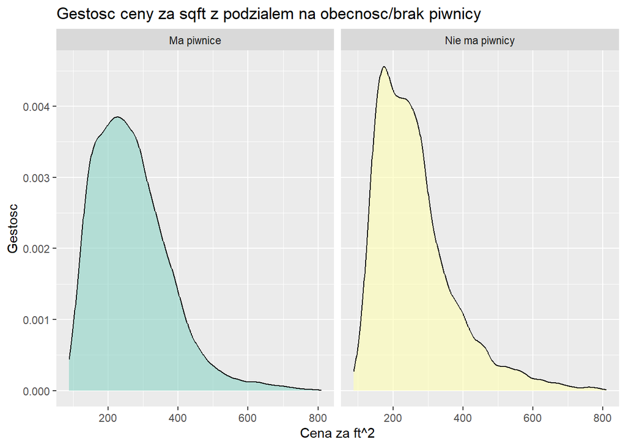

```r
# Tu umieść kod do wygenerowania odpowiedzi do zadania.

dane2 <- df %>%
  mutate(has_basement = case_when(sqft_basement == 0 ~ "Nie ma piwnicy",
                                  TRUE ~ "Ma piwnice"))


wyk2 <- ggplot(dane2, aes(x = price/sqft_living, fill = has_basement)) +
  geom_density(alpha = 0.6) +
  facet_wrap(~has_basement) +
  labs(title = "Gestosc ceny za sqft z podzialem na obecnosc/brak piwnicy",
       x = "Cena za ft^2",
       y = "Gestosc") +
  theme(legend.position = "none") +
  scale_fill_brewer(palette = "Set3")


wyk2
```

**Komentarz: Tak, dla domów bez piwnic było więcej cen około 180$ za sqft, ale dla domów z piwnicami było mniej cen powyżej 500$ za sqft.**

## Zadanie 3

Jaka jest zależność pomiędzy jakością wykończenia nieruchomości a liczbą pięter?

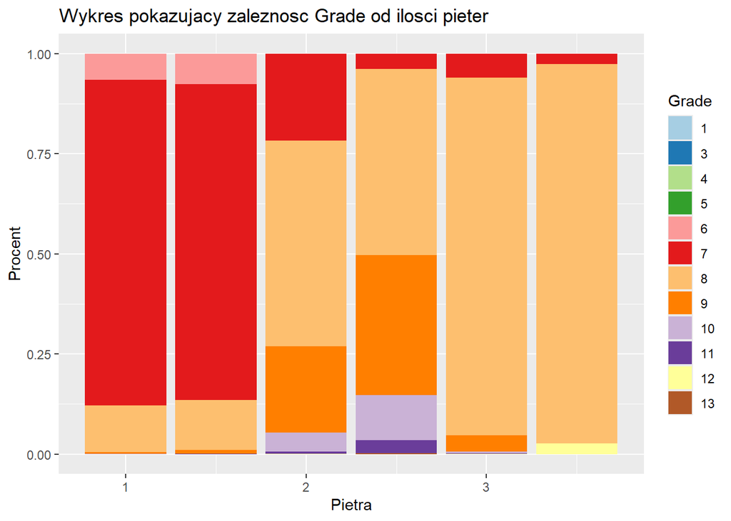

```r
# Tu umieść kod do wygenerowania odpowiedzi do zadania.

dane3 <-df %>%
  group_by(floors, grade) %>%
  mutate(num_same = n()) %>%
  ungroup() %>%
  mutate(Grade = as.character(grade), Grade = fct_reorder(Grade, grade))





wyk3 <- ggplot(dane3, aes(fill=Grade, y=num_same, x=floors)) +
  geom_bar(position="fill", stat="identity") +
  scale_fill_brewer(palette = "Paired") +
  labs(title = "Wykres pokazujacy zaleznosc Grade od ilosci pieter",
     x = "Pietra", y = "Procent")

wyk3
```

## Zadanie 4

Jaka jest zależność między powierzchnią mieszkalną nieruchomości a powierzchnią gruntu w podziale na liczbę sypialni?

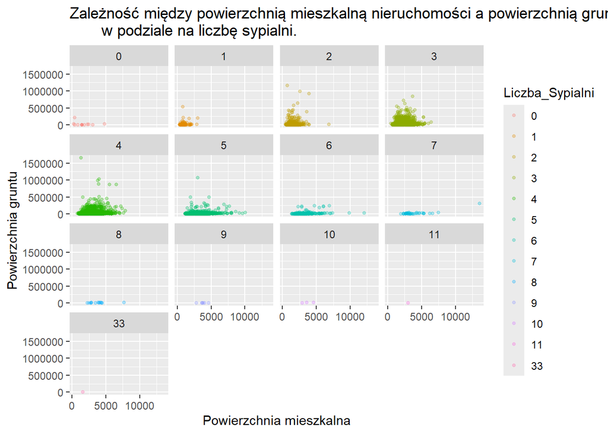

```r
# Tu umieść kod do wygenerowania odpowiedzi do zadania.

dane4 <- df %>%
  mutate(Liczba_Sypialni = as.character(bedrooms), Liczba_Sypialni = fct_reorder(Liczba_Sypialni, bedrooms))



wyk4 <- ggplot(dane4, aes(x = sqft_living, y = sqft_lot)) +
  geom_point(aes(color = Liczba_Sypialni), size = 1, alpha = 0.3) +
  facet_wrap(~Liczba_Sypialni) +
  labs(title = "Zależność między powierzchnią mieszkalną nieruchomości a powierzchnią gruntu,
       w podziale na liczbę sypialni.",
       x = "Powierzchnia mieszkalna",
       y = "Powierzchnia gruntu")


wyk4
```

**Komentarz: Dla domów mających 1-5 sypialnie widać, że przy najmniejszych lub największych powierzchniach mieszkalnych występują najmniejsze powierzchnie gruntu. Pozostałe domy mają generalnie mało powierzchnie gruntu**

## Zadanie 5

Rozważmy tylko nieruchomości, które miały remont. W której dekadzie było najwięcej przeprowadzonych remontów? Czy w poszczególnych dekadach jest porównywalny procent nieruchmości dla każdej wartości miary jakości i wykończenia nieruchomości?

[figure not shown]

```r
# Tu umieść kod do wygenerowania odpowiedzi do zadania.

dane5 <- df %>%
  filter(yr_renovated != 0) %>%
  mutate(Decade = as.character((as.numeric(yr_renovated) %/% 10)*10))  %>%
  select(Decade, grade) %>%
  group_by(Decade) %>%
  mutate(num_in_decade = n()) %>%
  ungroup() %>%
  group_by(Decade, grade) %>%
  mutate(num_same = n()) %>%
  ungroup() %>%
  mutate(Grade = as.character(grade), Grade = fct_reorder(Grade, grade))




wyk5_procenty_grade <- ggplot(dane5, aes(y=num_same, x=Decade, fill=Grade)) +
  geom_bar(position="fill", stat="identity") +
  scale_fill_brewer(palette = "Paired") +
  labs(title = "Zaleznosc Grade od ilosci pieter",
     x = "Dekady", y = "Procent")

wyk5_liczba_remontow <- ggplot(dane5 %>%
                                 group_by(Decade, num_in_decade) %>%
                                 slice(1)
                               , aes(x = as.numeric(Decade), y = num_in_decade)) +
  geom_line() +
  labs(title = "Liczba nieruchomości, które miały remont w dekadach",
     x = "Dekady", y = "Liczba nieruchomosci")

grid.arrange(wyk5_liczba_remontow, wyk5_procenty_grade, ncol = 1)
```

**Komentarz: Najwięcej remontów było w dekadzie 2000. W poszczególnych dekadach nie ma porównywalnego procenta domów takiego samego grade. Widać, że do dekady 2000 jest procentowo coraz więcej domów o wyższym grade.**

## Zadanie 6

Jak prezentuje się wartość minimalna, średnia i maksymalna ceny nieruchmości w podziele na rok budowy nieruchomości.

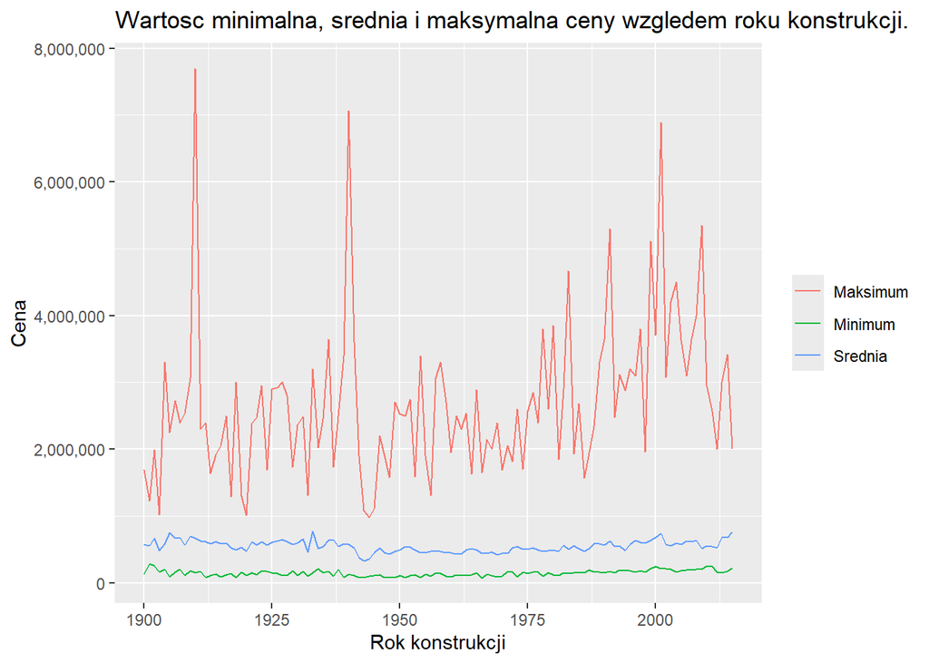

```r
# Tu umieść kod do wygenerowania odpowiedzi do zadania.

dane6 <- df %>%
  group_by(yr_built) %>%
  mutate(Minimum = min(price), Srednia = mean(price), Maksimum = max(price)) %>%
  ungroup() %>%
  select(yr_built, Minimum, Srednia, Maksimum) %>%
  group_by(yr_built, Minimum, Srednia, Maksimum) %>%
  slice(1) %>%
  ungroup() %>%
  pivot_longer(cols = any_of(c("Minimum", "Srednia", "Maksimum")),
               names_to = "price_stat_type",
               values_to = "price_stat")


wyk6 <- ggplot(dane6, aes(x = yr_built, y = price_stat, color = price_stat_type)) +
  geom_line() +
  labs(title = "Wartosc minimalna, srednia i maksymalna ceny wzgledem roku konstrukcji.",
     x = "Rok konstrukcji", y = "Cena") +
  scale_y_continuous(labels = scales::comma_format()) +
  theme(legend.title = element_blank())



wyk6
```

**Komentarz: Wartość minimalna utrzymuje się na tym samym poziomie dla każdego roku konstrukcji. Średnia różni się już bardziej w zależności od roku konstrukcji. Wartość maksymalna znacząco się różni w zależności od roku konstrukcji, ale dla domów zbudowanych po 1975 widać powolny wzrost.**